# Taller 6: Regresión Lineal Simple en R

Métodos Cuantitativos II

M. Constanza Ayala  
maria.ayala@uv.cl  
[Agenda una reunión aquí](https://outlook.office.com/bookwithme/user/6c3f9a95bb9d4c71abbc4d73b48d50d6@uv.cl/meetingtype/HPNElmMJ_UCckWs5QZTpdw2?anonymous&ismsaljsauthenabled&ep=mLinkFromTile)

Escuela de Sociología - Universidad de Valparaíso

22 de abril, 2026

## Pasemos lista mientras descargan los materiales y dejamos todo listo ✨

📂 **Paso 1:** Abrimos nuestro proyecto con doble clic en el archivo `.Rproj`

- Si no tienen proyecto, creamos uno: `File > New Project > New Directory > New Project`
- Creamos carpetas: `data`, `scripts`, `figures`, `output`

💾 **Paso 2:** Movemos el archivo **Script Taller 6 Métodos Cuantitativos II.R** a la carpeta `scripts`

📎 **Paso 3:** Verificamos que la base **Base de datos Casen 2022.Rdata** esté en la carpeta `data`

> **Todos los materiales los pueden descargar en este link: [Materiales clases](https://github.com/mconstanzaa/met-cuanti-ii-uv-2026)**

## Evaluación 3

Hoy tenemos nuestra **tercera evaluación individual** en R. Debes entregar lo siguiente:

- Proyecto de R (.Rproj).
- El script (.R) que contiene todos los ejercicios individuales solicitados en este taller. Debes crear un script nuevo, no utilices el script de actividades entregado en la clase.
  - En ese script, incluye un título, tu nombre, correo y fecha. Por ejemplo:

```r
# Script Ejercicio 3 Métodos Cuantitativos II --------------------------------------------
# M. Constanza Ayala (maria.ayala@uv.cl)
# 22-04-2026
```

**Plazo de entrega:** hoy hasta las 23:59 hrs. en el Aula Virtual.

> En caso de utilizar IA, debe reportarlo en un archivo Word, indicando la herramienta y los prompts usados. El uso no reportado será calificado con nota mínima.

## Objetivos de la clase

- **Preparar** variables y explorar descriptivamente la relación entre ellas
- **Estimar** modelos de regresión lineal simple con `lm()`
- **Evaluar la bondad de ajuste**: $R^2$ y ANOVA
- **Interpretar** coeficientes no estandarizados y estandarizados

## ¿Qué vimos la semana pasada en R?

✅ Recodificamos valores perdidos con `mutate()` y `across()`

✅ Calculamos correlaciones de Pearson con `cor()` y `cor.test()`

✅ Construimos matrices de correlación con `tab_corr()` y mapas de calor con `ggplot2`

💡 Hoy avanzamos hacia el **análisis de regresión lineal simple**.

## Base de datos: Encuesta CASEN 2022

Trabajaremos con la **Encuesta de Caracterización Socioeconómica Nacional (CASEN 2022)**, aplicada entre noviembre 2022 y febrero 2023.

- **n = 202.231** personas
- Cobertura nacional, representativa a nivel regional
- Organismo responsable: Ministerio de Desarrollo Social y Familia

Las variables que usaremos hoy:

| Variable | Descripción | Escala |
| --- | --- | --- |
| `ytrabajocor` | Ingreso del trabajo (corregido) | Pesos CLP |
| `esc` | Años de escolaridad | 0–29 |
| `edad` | Edad | 0–120 |
| `sexo` | Sexo | 1 Hombre / 2 Mujer |

## Preparación del entorno

```r
# Ajustes previos ---------------------------------------------------------
options(scipen = 999)

# Paquetes ----------------------------------------------------------------
library(tidyverse)
library(sjPlot)

# Base de datos -----------------------------------------------------------
load("data/Casen 2022_filter.Rdata")

# Vista previa
data %>% glimpse()
```

```
Rows: 202,231
Columns: 9
$ folio       <dbl> 100090101, 100090101, 100090101, 100090201, 100090201, 100…
$ id_persona  <dbl> 1, 2, 3, 1, 2, 3, 4, 1, 2, 3, 1, 2, 1, 1, 2, 3, 4, 1, 2, 1…
$ edad        <dbl> 72, 67, 40, 56, 25, 2, 60, 84, 67, 30, 64, 62, 59, 34, 30,…
$ sexo        <dbl> 2, 1, 2, 1, 2, 1, 2, 1, 2, 1, 1, 2, 2, 1, 2, 2, 2, 1, 2, 2…
$ genero      <dbl> 2, NA, 2, NA, 2, NA, 2, 1, 2, NA, 1, 2, 2, 1, 2, NA, NA, 1…
$ esc         <dbl> 1, 4, 15, NA, 12, NA, 10, 4, 8, 12, 5, 2, 5, 12, 12, NA, N…
$ ytrabajocor <dbl> NA, NA, 411242, NA, NA, NA, NA, NA, NA, NA, 590000, NA, NA…
$ yautcor     <dbl> 10000, 14000, 411242, NA, NA, NA, NA, 60000, 100000, NA, 5…
$ tot_per_h   <dbl> 3, 3, 3, 4, 4, 4, 4, 3, 3, 3, 2, 2, 1, 4, 4, 4, 4, 2, 2, 2…
```

## Preparación de variables

Para el análisis, trabajaremos con personas **en edad laboral activa** (25–65 años) que **declararon ingresos del trabajo**. Esto reduce el sesgo generado por grupos sin participación laboral típica (estudiantes, jubilados):

```r
data_trabajo <- data %>%
  filter(edad >= 25 & edad <= 65,
         !is.na(ytrabajocor),
         ytrabajocor > 0,
         !is.na(esc))

# Etiqueta para sexo
data_trabajo <- data_trabajo %>%
  mutate(sexo = factor(sexo,
                       levels = c(1, 2),
                       labels = c("Hombre", "Mujer")))

dim(data_trabajo)
```

```
[1] 75080     9
```

## Exploración descriptiva

```r
# Estadísticos descriptivos
data_trabajo %>%
  select(Ingreso = ytrabajocor, Escolaridad = esc, Edad = edad) %>%
  pivot_longer(everything(), names_to = "variable", values_to = "valor") %>%
  summarise(
    Media = mean(valor, na.rm = TRUE),
    DE    = sd(valor, na.rm = TRUE),
    Min   = min(valor, na.rm = TRUE),
    Max   = max(valor, na.rm = TRUE),
    .by = variable
  )
```

```
# A tibble: 3 × 5
  variable       Media        DE   Min      Max
  <chr>          <dbl>     <dbl> <dbl>    <dbl>
1 Ingreso     711454.  839505.      83 50966668
2 Escolaridad     12.4      3.77     0       26
3 Edad            43.8     11.5     25       65
```

```r
# Distribución por sexo
data_trabajo %>%
  group_by(Sexo = sexo) %>%
  summarise(
    N          = n(),
    Porcentaje = round(100 * n() / nrow(data_trabajo), 1)
  )
```

```
# A tibble: 2 × 3
  Sexo       N Porcentaje
  <fct>  <int>      <dbl>
1 Hombre 41085       54.7
2 Mujer  33995       45.3
```

## Actividad 1 para ejercicio

En una sección del script llamada `Preparación`:

1. Carga los paquetes `tidyverse` y `sjPlot`.
2. Importa la base `Base de datos Casen 2022.Rdata` con `load()` y explórala con `glimpse()`.
3. Crea el objeto `data_osig` aplicando los siguientes filtros con `filter()`:
   - Personas en edad laboral activa: `edad >= 25 & edad <= 65`
   - Con respuesta válida en `genero` (excluye `-88` y `-99`)
   - Con ingreso autónomo declarado y positivo: `!is.na(yautcor)` y `yautcor > 0`
4. Recodifica `genero` con `case_when()` en tres categorías: `"Femenino"` (valor 2), `"Masculino"` (valor 1), `"Otro"` (valores 3, 4, 5 y 6).
5. Calcula estadísticos descriptivos de `yautcor` y `tot_per_h` con `summarise()`. Incluye en comentarios (`#`): ¿cuántas personas quedaron en la muestra luego del filtro? ¿Cuál es el ingreso autónomo promedio?

## Repaso: la lógica de la regresión lineal simple

El modelo de regresión lineal simple a nivel muestral estima la ecuación:

$$\hat{Y}_i = \hat{b}_0 + \hat{b}_1 X_i$$

Donde:

- $\hat{Y}_i$: valor predicho de la variable dependiente
- $\hat{b}_0$: intercepto — valor esperado de $Y$ cuando $X = 0$
- $\hat{b}_1$: pendiente — cambio esperado en $Y$ por cada unidad adicional de $X$

**Pregunta guía de hoy:**

¿En qué medida los años de escolaridad predicen el ingreso del trabajo en Chile (CASEN 2022)?

## Visualización previa

Antes de estimar el modelo, exploramos la relación entre escolaridad e ingreso con un diagrama de dispersión:

```r
ggplot(data_trabajo, aes(x = esc, y = ytrabajocor)) +
  geom_point(alpha = 0.05) +
  geom_smooth(method = "lm", color = "steelblue", se = TRUE) +
  scale_y_continuous(labels = scales::label_number(big.mark = ".", decimal.mark = ",")) +
  labs(
    title = "Escolaridad e ingreso del trabajo",
    x = "Años de escolaridad",
    y = "Ingreso del trabajo (CLP)",
    caption = "Fuente: Encuesta CASEN 2022"
  ) +
  theme_minimal()
```

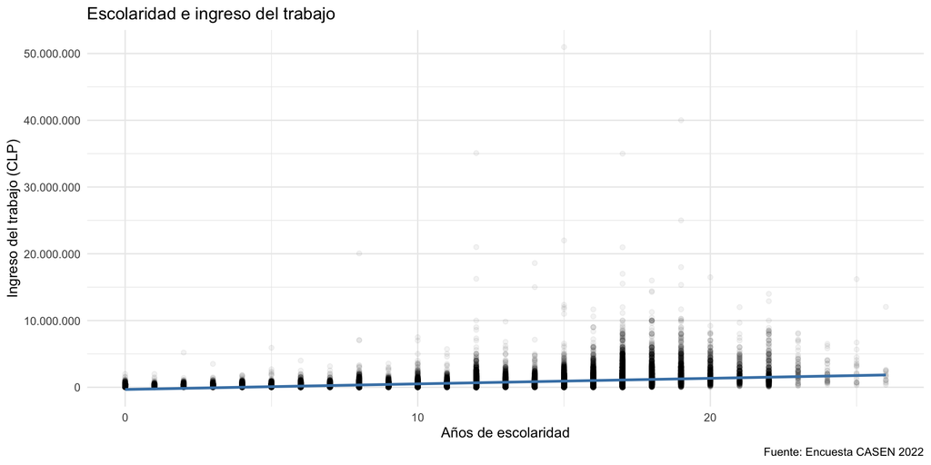

## `lm()`: estimación del modelo

La función `lm()` estima modelos de regresión por mínimos cuadrados ordinarios (MCO):

```r
# Modelo 1: escolaridad → ingreso del trabajo
m1 <- lm(ytrabajocor ~ esc, data = data_trabajo)

# Modelo 2: edad → ingreso del trabajo
m2 <- lm(ytrabajocor ~ edad, data = data_trabajo)

# Modelo 3: sexo → ingreso del trabajo (variable categórica)
m3 <- lm(ytrabajocor ~ sexo, data = data_trabajo)
```

> `lm(VD ~ VI, data = base)` es la sintaxis básica. R trata automáticamente las variables `factor` como variables *dummy*.

## Bondad de ajuste: `summary()`

Antes de leer los coeficientes, evaluamos cuánta varianza de $Y$ logra capturar el modelo:

```r
summary(m1)
```

```
Call:
lm(formula = ytrabajocor ~ esc, data = data_trabajo)

Residuals:
     Min       1Q   Median       3Q      Max
-1485439  -332929  -140725   152974 50041086

Coefficients:
             Estimate Std. Error t value            Pr(>|t|)
(Intercept) -327683.1     9789.5  -33.47 <0.0000000000000002 ***
esc           83551.0      753.3  110.92 <0.0000000000000002 ***
---
Signif. codes:  0 '***' 0.001 '**' 0.01 '*' 0.05 '.' 0.1 ' ' 1

Residual standard error: 778200 on 75078 degrees of freedom
Multiple R-squared:  0.1408,    Adjusted R-squared:  0.1408
F-statistic: 1.23e+04 on 1 and 75078 DF,  p-value: < 0.00000000000000022
```

## ¿Qué leemos en el output de `summary()`?

El output de `summary(lm())` entrega tres bloques clave:

**1. Residuos** — distribución de $e_i = Y_i - \hat{Y}_i$. Da una idea de cuánto se aleja el modelo de los valores observados.

**2. Coeficientes** — estimaciones de $\hat{b}_0$ y $\hat{b}_1$, con su error estándar, estadístico $t$ y p-valor. Contrasta $H_0: \hat{b}_1 = 0$ para cada predictor.

**3. Bondad de ajuste** — al final del output aparecen el estadístico $F$, su p-valor, $R^2$ y $R^2$ ajustado:

- El estadístico $F$ evalúa si el modelo en su conjunto capta varianza en $Y$ más allá del azar
- $R^2$: proporción de varianza de $Y$ capturada por el modelo (0 = nada, 1 = ajuste perfecto)
- El $R^2$ ajustado penaliza por el número de predictores; es más confiable para comparar modelos

## Interpretación: bondad de ajuste

A partir del output de `summary(m1)`:

- **Estadístico $F$ y p-valor global:** el modelo es estadísticamente significativo ($F$(1, 75078) = 12.300, $p$ < .001), lo que indica que la escolaridad capta varianza en el ingreso del trabajo más allá del azar.
- **$R^2$:** la escolaridad capta el 14% de la varianza en el ingreso del trabajo. Si bien es una proporción modesta, es esperable en ciencias sociales: el ingreso es un fenómeno multideterminado que un solo predictor no puede capturar en su totalidad.
- **$R^2$ ajustado:** en este modelo es idéntico al $R^2$ (0.14), lo que es esperable en regresión simple. La diferencia entre ambos se vuelve más relevante al comparar modelos con distinto número de predictores.

## Visualización de resultados: `tab_model()`

El paquete `sjPlot` permite visualizar los resultados de varios modelos en una tabla integrada. El argumento `show.std = TRUE` agrega los coeficientes estandarizados ($\beta$) directamente:

```r
tab_model(m1, m2,m3,
          show.se  = TRUE,
          show.std = TRUE,
          show.ci  = FALSE,
          dv.labels = c("Modelo 1", "Modelo 2", "Modelo 3"))
```

La tabla muestra para cada predictor:

- **B**: coeficiente no estandarizado (en unidades de $Y$)
- **SE**: error estándar de $b$
- **std. Beta** ($\beta$): coeficiente estandarizado
- **p**: p-valor para $H_0: \beta = 0$

|  | Modelo 1 |  |  |  |  | Modelo 2 |  |  |  |  | Modelo 3 |  |  |  |  |
| --- | --- | --- | --- | --- | --- | --- | --- | --- | --- | --- | --- | --- | --- | --- | --- |
| Predictors | Estimates | std. Error | std. Beta | standardized std. Error | p | Estimates | std. Error | std. Beta | standardized std. Error | p | Estimates | std. Error | std. Beta | standardized std. Error | p |
| (Intercept) | -327683.06 | 9789.55 | -0.00 | 0.00 | **<0.001** | 819094.88 | 12051.13 | -0.00 | 0.00 | **<0.001** | 794760.12 | 4117.04 | 0.10 | 0.00 | **<0.001** |
| Años de escolaridad (edad >= 15) | 83551.00 | 753.27 | 0.38 | 0.00 | **<0.001** |  |  |  |  |  |  |  |  |  |  |
| Edad |  |  |  |  |  | -2460.10 | 266.39 | -0.03 | 0.00 | **<0.001** |  |  |  |  |  |
| sexo: Mujer |  |  |  |  |  |  |  |  |  |  | -183986.30 | 6118.42 | -0.22 | 0.01 | **<0.001** |
| Observations | 75080 |  |  |  |  | 75080 |  |  |  |  | 75080 |  |  |  |  |
| R<sup>2</sup> / R<sup>2</sup> adjusted | 0.141 / 0.141 |  |  |  |  | 0.001 / 0.001 |  |  |  |  | 0.012 / 0.012 |  |  |  |  |

## Interpretación de coeficientes

Para el modelo `m1` (ingreso ~ escolaridad):

- **$\hat{b}_1$ (no estandarizado):** cada año adicional de escolaridad se asocia con un aumento esperado de $83.551$ pesos en el ingreso del trabajo. El coeficiente es estadísticamente significativo (p < .001).
- **$\hat{b}_0$ (intercepto):** el ingreso esperado para una persona con 0 años de escolaridad sería de –$327.683$ pesos. Este valor no tiene interpretación sustantiva, ya que un ingreso negativo no es posible y 0 años de escolaridad es un valor extremo en la muestra.
- **$\beta$ (estandarizado):** por cada desviación estándar de aumento en la escolaridad, el ingreso del trabajo aumenta $0.38$ desviaciones estándar. Indica un coeficiente de magnitud moderada.

## Un modelo con variable categórica: sexo

Las variables categóricas se incorporan al modelo como variables *dummy*. R crea automáticamente la variable indicadora al declarar el predictor como `factor` (recomendado) o `character` en la función `lm`.

|  | Ingreso del trabajo corregido |  |  |  |  |
| --- | --- | --- | --- | --- | --- |
| Predictors | Estimates | std. Error | std. Beta | standardized std. Error | p |
| (Intercept) | 794760.12 | 4117.04 | 0.10 | 0.00 | **<0.001** |
| sexo [Mujer] | -183986.30 | 6118.42 | -0.22 | 0.01 | **<0.001** |
| Observations | 75080 |  |  |  |  |
| R<sup>2</sup> / R<sup>2</sup> adjusted | 0.012 / 0.012 |  |  |  |  |

## Interpretación

- El ingreso esperado para un hombre es $794.760$ pesos
- El coeficiente de `sexo [Mujer]` indica que las mujeres tienen un ingreso esperado $183.986$ pesos menor que los hombres (p < .001)
- El $\beta$ = –0.22 indica que las mujeres tienen un ingreso 0.22 desviaciones estándar menor que los hombres

## Actividad 2 para ejercicio

En una sección llamada `Modelo 1 — género`, plantea en un comentario (`#`) una pregunta de investigación con `yautcor` como VD y `genero` como VI. Luego:

1. Estima el modelo con `lm()` y evalúa la bondad de ajuste con `summary()`. Interpreta en comentarios (`#`) el estadístico $F$, el p-valor global y el $R^2$.
2. Visualiza los coeficientes con `tab_model(show.std = TRUE)`. Interpreta en comentarios (`#`) el coeficiente $b$ y el $\beta$.

En una sección llamada `Modelo 2 — tamaño del hogar`, plantea en un comentario (`#`) una pregunta de investigación con `yautcor` como VD y `tot_per_h` como VI. Luego:

1. Estima el modelo con `lm()` y evalúa la bondad de ajuste con `summary()`. Interpreta en comentarios (`#`) el estadístico $F$, el p-valor global y el $R^2$.
2. Visualiza los coeficientes con `tab_model(show.std = TRUE)`. Interpreta en comentarios (`#`) el coeficiente $b$ y el $\beta$.

## ❓ Preguntas y aclaraciones

💬 **¿Dudas sobre lo visto hoy?**

- Tómense un momento para reflexionar y compartir preguntas sobre el contenido.
- Espacio para responder inquietudes y aclarar conceptos clave.

## Resumen de la clase de hoy

✅ Estimamos modelos de regresión lineal simple con `lm()`

✅ Evaluamos la bondad de ajuste con $R^2$ y ANOVA

✅ Interpretamos coeficientes no estandarizados ($b$) y estandarizados ($\beta$) con `tab_model()`

✅ Incorporamos una variable categórica como predictor (*dummy*)

## 📆 Próxima sesión

- Evaluación de supuestos del modelo de regresión lineal
- Regresión lineal múltiple en R

## 📚 Sugerencias lecturas para reforzar R

- Wickham & Grolemund. R for Data Science (en español: https://es.r4ds.hadley.nz/)
- [AnalizaR Datos Políticos](https://arcruz0.github.io/libroadp/index.html)
- [YaRrr! The Pirate’s Guide to R](https://bookdown.org/ndphillips/YaRrr/)